# Multilevel Modeling, Module 3: Intro to MLM and the Null Model

Dr. Broda

This week, we are going to use a larger version of the HSB dataset back from 1988. Same structure- students nested within schools. This is the same dataset that Garson uses in Chapter 3, so you can recreate what he has as well.

# Load Some Packages to Help with the Analysis and Data Management:

```r
library(tidyverse)
library(Hmisc) # label()
library(lme4)
library(lmerTest)
```

# Load in the Data and Use `glimpse` to Summarize the Data Structure

```r
hsb <- hsbmerged

glimpse(hsb)
```

```
Rows: 7,185
Columns: 11
$ schoolid <dbl> 1224, 1224, 1224, 1224, 1224, 1224, 1224, 1224, …
$ minority <dbl> 0, 0, 0, 0, 0, 0, 0, 0, 0, 0, 0, 0, 0, 0, 0, 0, …
$ female   <dbl> 1, 1, 0, 0, 0, 0, 1, 0, 1, 0, 1, 1, 0, 1, 0, 1, …
$ ses      <dbl> -1.528, -0.588, -0.528, -0.668, -0.158, 0.022, -…
$ mathach  <dbl> 5.876, 19.708, 20.349, 8.781, 17.898, 4.583, -2.…
$ size     <dbl> 842, 842, 842, 842, 842, 842, 842, 842, 842, 842…
$ sector   <dbl> 0, 0, 0, 0, 0, 0, 0, 0, 0, 0, 0, 0, 0, 0, 0, 0, …
$ pracad   <dbl> 0.35, 0.35, 0.35, 0.35, 0.35, 0.35, 0.35, 0.35, …
$ disclim  <dbl> 1.597, 1.597, 1.597, 1.597, 1.597, 1.597, 1.597,…
$ himinty  <dbl> 0, 0, 0, 0, 0, 0, 0, 0, 0, 0, 0, 0, 0, 0, 0, 0, …
$ meanses  <dbl> -0.428, -0.428, -0.428, -0.428, -0.428, -0.428, …
```

# Quick Data Cleaning and Coding Tips!

## The `summary` command from `base R` is a quick and easy way to explore a new dataset.

```r
summary(hsb)
```

```
    schoolid       minority          female
 Min.   :1224   Min.   :0.0000   Min.   :0.0000
 1st Qu.:3020   1st Qu.:0.0000   1st Qu.:0.0000
 Median :5192   Median :0.0000   Median :1.0000
 Mean   :5278   Mean   :0.2747   Mean   :0.5282
 3rd Qu.:7342   3rd Qu.:1.0000   3rd Qu.:1.0000
 Max.   :9586   Max.   :1.0000   Max.   :1.0000
      ses               mathach            size
 Min.   :-3.758000   Min.   :-2.832   Min.   : 100
 1st Qu.:-0.538000   1st Qu.: 7.275   1st Qu.: 565
 Median : 0.002000   Median :13.131   Median :1016
 Mean   : 0.000143   Mean   :12.748   Mean   :1057
 3rd Qu.: 0.602000   3rd Qu.:18.317   3rd Qu.:1436
 Max.   : 2.692000   Max.   :24.993   Max.   :2713
     sector           pracad          disclim
 Min.   :0.0000   Min.   :0.0000   Min.   :-2.4160
 1st Qu.:0.0000   1st Qu.:0.3200   1st Qu.:-0.8170
 Median :0.0000   Median :0.5300   Median :-0.2310
 Mean   :0.4931   Mean   :0.5345   Mean   :-0.1319
 3rd Qu.:1.0000   3rd Qu.:0.7000   3rd Qu.: 0.4600
 Max.   :1.0000   Max.   :1.0000   Max.   : 2.7560
    himinty        meanses
 Min.   :0.00   Min.   :-1.188000
 1st Qu.:0.00   1st Qu.:-0.317000
 Median :0.00   Median : 0.038000
 Mean   :0.28   Mean   : 0.006138
 3rd Qu.:1.00   3rd Qu.: 0.333000
 Max.   :1.00   Max.   : 0.831000
```

Summary gives you a quick, high-level summary of all the variables in a dataset. It is also really useful for your own records. You can just copy and paste into a Word file and have it for your records.

Now, data cleaning and coding! We’re going to learn how to apply labels to (1) variables themselves, and (2) the values within a given variable. Both are useful and a good practice for cleaning up your data.

## Let’s give some variables a label:

```r
label(hsb$mathach) = "Std. Math Score"
label(hsb$sector) = "School Sector"

str(hsb$sector)
```

```
 'labelled' num [1:7185] 0 0 0 0 0 0 0 0 0 0 ...
 - attr(*, "label")= chr "School Sector"
```

## Let’s create a factor version of `sector` and give specific values of `sector` a label:

```r
hsb.clean <- hsb %>%
  mutate(.,
         sector.factor = as_factor(sector),
         female.factor = as_factor(female),
         minority.factor = as_factor(minority))

levels(hsb.clean$sector.factor) = c("Public", "Parochial")
levels(hsb.clean$female.factor) = c("Male", "Female")
levels(hsb.clean$minority.factor) = c("Non-Minority", "Minority")

str(hsb.clean$sector.factor)
```

```
 Factor w/ 2 levels "Public","Parochial": 1 1 1 1 1 1 1 1 1 1 ...
 - attr(*, "label")= chr "School Sector"
```

```r
table(hsb.clean$sector.factor)
```

```
   Public Parochial
     3642      3543
```

## Run `summary` again - notice how it handles factors…

```r
summary(hsb.clean)
```

```
    schoolid       minority          female
 Min.   :1224   Min.   :0.0000   Min.   :0.0000
 1st Qu.:3020   1st Qu.:0.0000   1st Qu.:0.0000
 Median :5192   Median :0.0000   Median :1.0000
 Mean   :5278   Mean   :0.2747   Mean   :0.5282
 3rd Qu.:7342   3rd Qu.:1.0000   3rd Qu.:1.0000
 Max.   :9586   Max.   :1.0000   Max.   :1.0000
      ses               mathach            size
 Min.   :-3.758000   Min.   :-2.832   Min.   : 100
 1st Qu.:-0.538000   1st Qu.: 7.275   1st Qu.: 565
 Median : 0.002000   Median :13.131   Median :1016
 Mean   : 0.000143   Mean   :12.748   Mean   :1057
 3rd Qu.: 0.602000   3rd Qu.:18.317   3rd Qu.:1436
 Max.   : 2.692000   Max.   :24.993   Max.   :2713
     sector           pracad          disclim
 Min.   :0.0000   Min.   :0.0000   Min.   :-2.4160
 1st Qu.:0.0000   1st Qu.:0.3200   1st Qu.:-0.8170
 Median :0.0000   Median :0.5300   Median :-0.2310
 Mean   :0.4931   Mean   :0.5345   Mean   :-0.1319
 3rd Qu.:1.0000   3rd Qu.:0.7000   3rd Qu.: 0.4600
 Max.   :1.0000   Max.   :1.0000   Max.   : 2.7560
    himinty        meanses            sector.factor  female.factor
 Min.   :0.00   Min.   :-1.188000   Public   :3642   Male  :3390
 1st Qu.:0.00   1st Qu.:-0.317000   Parochial:3543   Female:3795
 Median :0.00   Median : 0.038000
 Mean   :0.28   Mean   : 0.006138
 3rd Qu.:1.00   3rd Qu.: 0.333000
 Max.   :1.00   Max.   : 0.831000
     minority.factor
 Non-Minority:5211
 Minority    :1974
```

# Exploring Our Outcome, Match Achievement

## Now, let’s take a look at the `mathach` variable using the `describe` function from the `Hmisc` package:

```r
describe(hsb.clean$mathach)
```

```
hsb.clean$mathach : Std. Math Score
       n  missing distinct     Info     Mean      Gmd      .05
    7185        0     6031        1    12.75     7.91    1.210
     .10      .25      .50      .75      .90      .95
   3.301    7.275   13.131   18.317   22.016   23.123

lowest : -2.832 -2.830 -2.721 -2.658 -2.657
highest: 24.677 24.707 24.812 24.869 24.993
```

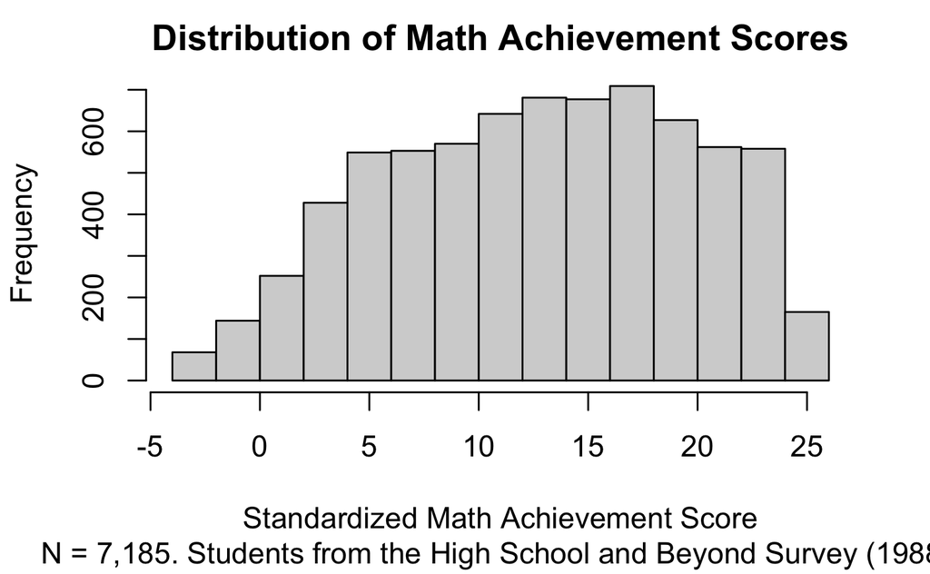

```r
hist(hsb.clean$mathach,
     main = "Distribution of Math Achievement Scores",
     sub = "N = 7,185. Students from the High School and Beyond Survey (1988).",
     xlab = "Standardized Math Achievement Score")
```

# Running a Null Model

```r
model.null <- lmer(mathach ~ (1|schoolid), REML = FALSE, data = hsb.clean)
summary(model.null)
```

```
Linear mixed model fit by maximum likelihood . t-tests use
  Satterthwaite's method [lmerModLmerTest]
Formula: mathach ~ (1 | schoolid)
   Data: hsb.clean

     AIC      BIC   logLik deviance df.resid
 47121.8  47142.4 -23557.9  47115.8     7182

Scaled residuals:
     Min       1Q   Median       3Q      Max
-3.06262 -0.75365  0.02676  0.76070  2.74184

Random effects:
 Groups   Name        Variance Std.Dev.
 schoolid (Intercept)  8.553   2.925
 Residual             39.148   6.257
Number of obs: 7185, groups:  schoolid, 160

Fixed effects:
            Estimate Std. Error       df t value Pr(>|t|)
(Intercept)  12.6371     0.2436 157.6209   51.87   <2e-16 ***
---
Signif. codes:  0 ‘***’ 0.001 ‘**’ 0.01 ‘*’ 0.05 ‘.’ 0.1 ‘ ’ 1
```

You also get AIC and BIC, two very common information criterion measures that are used to assess model fit:

# Post-Estimation Task: Calculate ICC

These commands are run after you an any kind of MLM. They are called post-estimation commands because they require that you have the model saved in the memory (it is the last thing you ran). If you do something else and try to run them, you will likely get an error.

Here’s a quick and easy way to get our friend the ICC!

```r
null.ICC <- 8.553/(8.553 + 39.148)
null.ICC
```

```
[1] 0.1793044
```

# Using `lmerTest` to Evaluate Random Effects:

```r
rand(model.null)
```

```
ANOVA-like table for random-effects: Single term deletions

Model:
mathach ~ (1 | schoolid)
               npar logLik   AIC    LRT Df Pr(>Chisq)
<none>            3 -23558 47122
(1 | schoolid)    2 -24050 48104 983.92  1  < 2.2e-16 ***
---
Signif. codes:  0 ‘***’ 0.001 ‘**’ 0.01 ‘*’ 0.05 ‘.’ 0.1 ‘ ’ 1
```

# Always Interesting: Compare Our MLM to a Regular Regression

```r
model.regular <- lm(mathach ~ NULL, data = hsb.clean)
summary(model.regular)
```

```
Call:
lm(formula = mathach ~ NULL, data = hsb.clean)

Residuals:
Std. Math Score
     Min       1Q   Median       3Q      Max
-15.5799  -5.4729   0.3831   5.5691  12.2451

Coefficients:
            Estimate Std. Error t value Pr(>|t|)
(Intercept) 12.74785    0.08115   157.1   <2e-16 ***
---
Signif. codes:  0 ‘***’ 0.001 ‘**’ 0.01 ‘*’ 0.05 ‘.’ 0.1 ‘ ’ 1

Residual standard error: 6.878 on 7184 degrees of freedom
```